# MHT p value correction

21/12/2021

**Author: [Miguel García](https://angelcampos.github.io/)**

[Multiple hypothesis testing](https://en.wikipedia.org/wiki/Multiple_comparisons_problem#Definition) (MHT) occurs when a statistical analysis involves multiple simultaneous statistical tests, each of which has a potential to produce a “discovery” (namely, rejecting the null hypothesis), on the **same dataset**. A common example in the Life Sciences field arose when we were able to measure multiple genes in the same experiment and we wanted to know which genes were differentially expressed between control and a treatment groups; but it could apply to any experiment in which we obtain measurements for multiple features and we want to perform a statistical test for each of the features. Nevertheless when performing MHT a problem arises.

The so called [Multiple comparison problem](https://en.wikipedia.org/wiki/Multiple_comparisons_problem), a.k.a. [Look-elsewhere effect](https://en.wikipedia.org/wiki/Look-elsewhere_effect), is that **the more inferences are made, the more likely erroneous** **inferences are to occur**. Several statistical techniques have been developed to prevent this from happening, allowing significance levels for single and multiple comparisons to be directly compared. These techniques generally require a stricter significance threshold for individual comparisons, to compensate for the number of inferences being made. We can also see this methods as a way to **correct the p Values** obtained from the MHT procedure. To further understand the multiple comparison problem I have prepared the following material to simulate MHT experiments and their outcomes when we are expecting normally distributed values (similar approaches would apply to data from other theorethical distributions).

# Multiple Hypothesis, why correcting?

Multiple Hypothesis Testing (MHT) p Value correction becomes evident when simulating experiments with known distributions and their outcome.

The MHE() function bellow simulates a MHT experiment, creates **nFeatures** sampling **nSample** “measurements” from two *normal distributions* with means **popMean1** and **popMean2** with a standard deviation of **popSD** for both cases; then it calculates a p Value with a t-test for each feature. The output of the function is a dataframe of the resulting p Values for each feature in the column **raw**, which stands for p Values that have not been corrected.

This function will help us create artificial data and p Values here on.

```r
MHE <- function(nFeatures, nSample, popMean1, popMean2, popSD){
  data.frame(raw = unlist(lapply(1:nFeatures, function(x){
    smp1 <- rnorm(nSample, popMean1, popSD)
    smp2 <- rnorm(nSample, popMean2, popSD)
    t.test(smp1, smp2)$p.value
  })))
}
```

In the following example we create 10’000 features with both theoretical populations having the same mean value of 100, which would be akin to measure ten thousand genes in treatment and control, when the treatment has no effect at all, and test for differences

> Gene counts from RNA-seq methods do not distribut normally, currently one of the theoretical distributions to model gene counts is the [Negative binomial distribution](https://en.wikipedia.org/wiki/Negative_binomial_distribution) but for practical purposes here we use the normal distribution.

In theory the samples should have the same mean and there should be no differences, but due to chance we can pick measurements that are very different from one another and seem that they come from different distributions. When applying a t-test to such samples we will obtain a small p-value. Using a statistical threshold = 0.05 we guard against false postives 95% of the times, when performing only one inference.

> *For practical purposes we are using the same mean for all feature simulations but in real experiments the mean for each feature can be different yet we will have the same outcome.*

```r
set.seed(2020) # Seed for reproducibility purposes
nFeat <- 1e4 # Number of features
pVals <- MHE(nFeatures = nFeat, nSample = 10, popMean1 = 100, popMean2 = 100, popSD = 10)
```

Plotting the distribution of the p values we can appreciate that they distribute uniformly, we have almost the same chance of having a p-value between 0 and 0.1 and between 0.9 and 1.

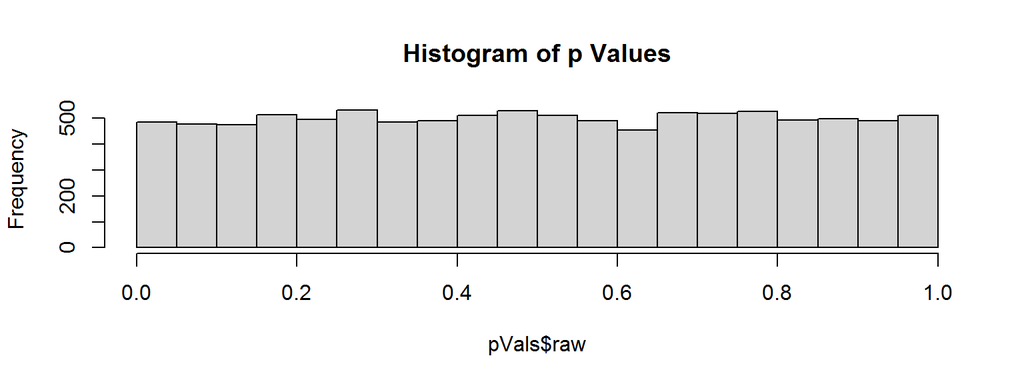

```r
hist(pVals$raw, main = "Histogram of p Values")
```

If we check the proportion of tests with a p Value bellow a singnificance threshold of = 0.05, we will observe that it is close to 5%, which is similar to our alpha. It should become now evident how a p Value tries to control for False positives, as due to chance we can obtain a discovery where there should not be.

```r
alpha <- 0.05
sum(pVals$raw < alpha) / nFeat
```

```
## [1] 0.0484
```

By ploting the Empirical Cumulative Distribution Function (ECDF) of the p values distribution, we appreciate that is like a straight line from 0,0 to 1,1. This indicates that there is roughly the same chance of falling at any interval.

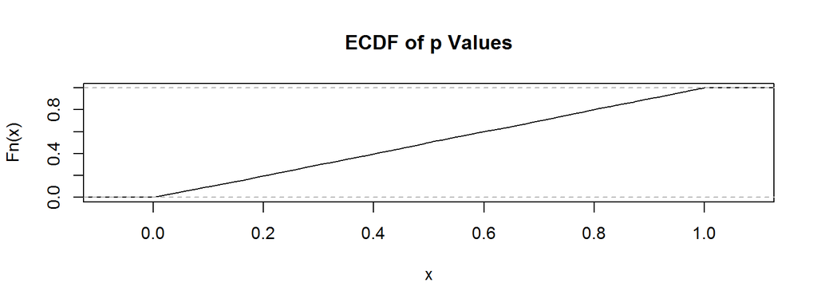

```r
plot(ecdf(pVals$raw), main = "ECDF of p Values")
```

If we wanted to know the probability of our MHT experiments that will have false discoveries using and no correction we would be calculating the [Family-wise Error Rate (FWER)](https://en.wikipedia.org/wiki/Family-wise_error_rate)

The FWER, is given by the formula:

$$FWER = 1 - (1 - \alpha )^m$$

In our original case with 10’000 tests FWER = 1 - 1.722078e-223, which means that virtually our experiment will ALWAYS have false discoveries; and when there are too many false discoveries it will be hard to set a threshold to tell which ones are real and which are not.

Having false discoveries is undesirable but more so is never having the ability to come with plaussible statistically validated discoveries, which prompts the need to control for this theoretical impasse.

# Family-wise Error Rate (FWER) control

## Bonferroni correction method

The Bonferroni correction attempts to bring the FWER to the initial confidence level value. So that only 5% of our experiments run with MHT have false discoveries.

To achieve this each test is evaluated at a confidence value divided by the number of tests. Which is equivalent to multiply the p values by the number of tests (with an upper threshold of 1, as p Values cannot be higher than 1).

Then we can evaluate at the original confidence value. Bellow we can define a function that implements the Bonferroni correction.

```r
bonferroni_correction <- function(p){
  pTmp <- p * length(p)
  pTmp <- sapply(pTmp, function(x){
    min(x, 1)
  })
  return(pTmp)
}
```

And then apply it to our “raw” p Values.

```r
pVals$bonferroni <- bonferroni_correction(pVals$raw)
sum(pVals$bonferroni < 0.05)
```

```
## [1] 0
```

Now we have 0 p values that are smaller than the confidence level. Which is good as in our original example there are no difference between sample populations. By using the Bonferroni correction method we have made it less likely to have a false discovery, we would need to perform hundreds of MHT experiments to again reach to the expected 5% chance of having at least one false discovery in the whole experiment.

But what if we truly have different means in the population? We can run the same simulation but with popMean1 = 100 and popMean2 = 120, a relatively large difference, and then apply the bonferroni correction to prevent false discoveries.

> Remember: In these simulations we know that the means of the populations are indeed different but in real experiments we don’t, so we still would need to apply a p Value correction method.

```r
pVals2 <- MHE(nFeatures = nFeat, nSample = 10, popMean1 = 100, popMean2 = 120, popSD = 10)
pVals2$bonferroni <- bonferroni_correction(pVals2$raw)
mean(pVals2$bonferroni < 0.05)
```

```
## [1] 0.0864
```

In this example, around 8% of the tests are able to reject the null hypothesis after using the Bonferroni correction. **When in reality all of them should have** **been rejected!**

Bonferroni correction is too conservative and losing so many true discoveries is not desirable on many instances, specially if obtaining the data requires a lot of resources, as Life Sciences research. That is why other methods have to be developed.

## Hochberg correction method

Yosef Hochber in [1988](http://www-stat.wharton.upenn.edu/~steele/Courses/956/Resource/MultipleComparision/Hochberg88.pdf) presented a slightly more powerful procedure (able to detect more real differences than bonferroni) in which the p values are evaluated from biggest to smallest.

The biggest p value is evaluated with the original confidence level (α), if the p value is smaller then all subsequent hypothesis are rejected, if not the next biggest p-value is tested with a confidence level of α/2, and so on.

This would be similar to multiplying the smallest p value by the number of tests, then the second p value by the number of tests minus 1, and so on until this operation yields a bigger number than the biggest original p value at which point all subsequent p values will be assigned that same p value. Again we can implement this function using R!

```r
hochberg_correction <- function(p){
  oNames <- names(p) # save the original names if there are
  names(p) <- seq_along(p)
  pTmp <- sort(p, decreasing = FALSE)
  pTmp <- pTmp * (length(p):1)
  pTmp[which(pTmp > max(p))] <- max(p)
  pAdj <- pTmp[order(as.numeric(names(pTmp)))] #Sort p values in original order
  names(pAdj) <- oNames #Original names (if any)
  return(pAdj)
}
```

Now we can use Hochberg’s correction method and see the proportion of rejected hypothesis

```r
pVals$hochberg <- hochberg_correction(pVals$raw)
pVals2$hochberg <- hochberg_correction(pVals2$raw)
mean(pVals2$hochberg < 0.05)
```

```
## [1] 0.0907
```

We had an improvement, from ~8% to ~9% rejected null hypothesis. Still too conservative given that the measurements were taken from reasonably different distributions. So there should be a way to be able to detect more TRUE differences, but still correcting for the influence of doing multiple testing. Maybe FWER control is too strict.

# False Discovery Rate (FDR) control

Both Bonferroni’s and Hochberg’s FWER control procedures are directed towards controlling the chance of having **at least one** false discovery. This method of statistical control has proven too stringent and in many cases makes impossible to detect plaussibly real differences in measurements. Reason why we needed other, perhaps less stringent, methods.

What if we could be less stringent, but yet have a statistical basis to control for the proportion of false discoveries? Or in other words the [False Discovery Rate](https://en.wikipedia.org/wiki/False_discovery_rate) (FDR).

FDR-controlling procedures are designed to control the expected proportion of discoveries that are false positives (incorrect rejections of the null hypothesis) in a MHT procedure. These methods provide less stringent control of False Positives compared to FWER-controlling methods, but have greater power.

## Benjamini-Hochberg method (FDR method)

The FDR concept was formally described by Yoav Benjamini and Yosef Hochberg in [1995](https://www.jstor.org/stable/2346101?seq=4#metadata_info_tab_contents) as a practical and powerfull approach at identifying the important few from the trivial many effects tested.

The Benjamini-Hochberg FDR method has been particularly influential, as it was the first alternative to the FWER methods to gain broad acceptance in many scientific fields, especially in Genomics, where experiments measuring hundreds to thousands of genes started to appear.

Altough the underlying theory can be daunting, the actual mathematical procedure is quite simple. And implemented in the function bellow.

1. Order p-values from smallest to largest.
2. Give a rank to the p-values (1 to smallest, n to largest).
3. The largest p value stays the same.
4. The next largest adjusted p-value is the smaller of two options:
1. The previous adjusted p value.
2. The original p value multiplied by the number of p Values divided by the rank of the p value we are adjusting.

> A nice illustation of the underlying logic can be found in a video by Josh Starmer (aka StatQuest) found on the references section at the end of this document.

```r
# Benjamin Hochberg FDR correction implementation
BH_correction <- function(p){
  oNames <- names(p) # save the original names if there are
  names(p) <- seq_along(p)
  pTmp <- sort(p, decreasing = FALSE)
  rank <- seq_along(pTmp)
  for(i in rev(head(rank, -1))){
    pA <- pTmp[i + 1] # The previous corrected p value
    pB <- pTmp[i] * length(p) / rank[i] # p value * number of p Values / rank
    pTmp[i] <- min(c(pA, pB)) # The minimum of both
  }
  pAdj <- pTmp[order(as.numeric(names(pTmp)))]
  names(pAdj) <- oNames
  return(pAdj)
}
```

The resulting adjusted p values are called **q Values**. Once we have them we can apply a threshold, which would be the rate of expected false discoveries. For example a common used threshold for q Values is 0.1. If we then reject hypothesis that have a smaller q Value, we will expect to have 10% of false discoveries, and 90% of true discoveries.

If we apply the FDR correction to our two previous examples 1) samples coming from the same distribution, and 2) samples coming from two different distributions, we can appreciate two effects: We have succesfully eliminated the false discoveries in the case where there shouldn’t be null hypothesis rejection; and in the case were there are differences we now are able to recover most of the real differences.

```r
pVals$FDR <- BH_correction(pVals$raw)
pVals2$FDR <- BH_correction(pVals2$raw)

FDR1 <- mean(pVals$FDR < 0.05)
FDR2 <- mean(pVals2$FDR < 0.05)
```

Proportion of Q values bellow 0.05, when the samples are extracted from the **same** distribution = 0

Proportion of Q values bellow 0.05, when the samples are extracted from **different** distribution = 0.9869

We can see the effect of the corrected p values in the form of boxplots shown bellow. We apply a -10log-transformation to see small p Values more easily, and draw a line which indicates the hypothesis that pass the threshold = 0.05. (Smaller p Values have bigger -log10 values)

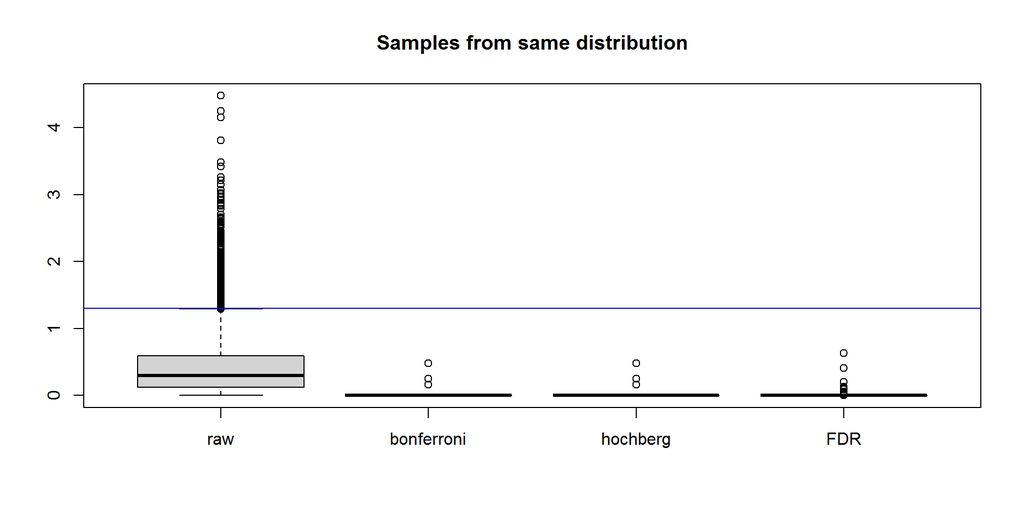

```r
boxplot(-log10(pVals), main = "Samples from same distribution")
abline(h = -log10(0.05), col = "blue", las = 2)
```

As we can see many tests reject the null hypothesis when we don’t make the correction, even when samples come from the same distribution, just by chance! But after correcting this effect is lost.

In the second example we sample from two different distributions, in which in principle we should reject the null hypothesis all the time, but when applying FWER controling methods we end up “over-correcting” thus having very few discoveries. However when using FDR controlling methods we still keep most of the TRUE positives.

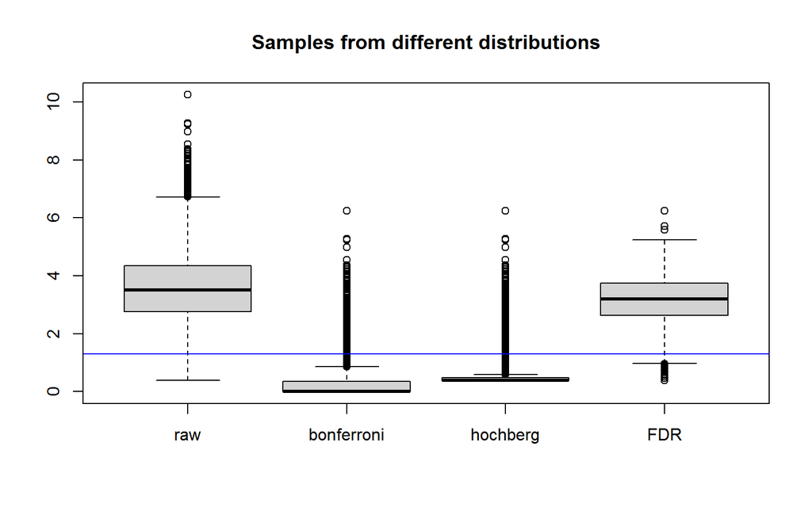

```r
boxplot(-log10(pVals2), main = "Samples from different distributions")
abline(h = -log10(0.05), col = "blue", las = 2)
```

# Epilogue

As R is a statistically oriented Programming language it already comes with a function that performs p Value correction. Which is `p.adjust()`.

You can correct pValues with different methods as stated in the help of the function, using the `method` argument. Bellow examples of how to perform each of the corrections done before.

```r
p.adjust(pVals$raw, method = "bonferroni")
p.adjust(pVals$raw, method = "hochberg")
p.adjust(pVals$raw, method = "fdr") # Also, p.adjust(pVals$raw, method = "BH")
```

I hope that this (hopefully brief) tutorial and the implementation of some p Value correction methods help you understand the reasons why we perform, how it is done, what we lose and what we gain by performing each of them.

> A special note has to be made with the use of the = 0.05 threshold. Here is only used for illustrative purposes, the interpretaion of a p Value **passing or not passing a certain** **threshold** for a result being “statistically significant” should should not be done without care and blind to the size effects. A more thorough discussion in this matter can be followed in the 2nd most popular article of 2019, as ranked by Altmetric [Scientists rise up against statistical significance](https://www.altmetric.com/top100/2019/?details=57358237).

# References

- Hochberg, Yosef. “A sharper Bonferroni procedure for multiple tests of significance.” Biometrika 75.4 (1988): 800-802. [URL](https://academic.oup.com/biomet/article/75/4/800/423177?login=true)
- Benjamini, Yoav, and Yosef Hochberg. “Controlling the false discovery rate: a practical and powerful approach to multiple testing.” Journal of the Royal statistical society: series B (Methodological) 57.1 (1995): 289-300. [URL](https://rss.onlinelibrary.wiley.com/doi/abs/10.1111/j.2517-6161.1995.tb02031.x)
- [Wikipedia: Family-wise Error Rate](https://en.wikipedia.org/wiki/Family-wise_error_rate)
- [Wikipedia: False Dicovery Rate](https://en.wikipedia.org/wiki/False_discovery_rate)
- [Recommended video: False Discovery Rates, FDR, clearly explained by Statquest](https://youtu.be/K8LQSvtjcEo)